# compile-regional-data

Salmon Watersheds Program, Steph Peacock, Hannah Hunter

March 10, 2026

# 1 Overview

The Pacific Salmon Foundation’s [State of Salmon Report](https://stateofsalmon.ca) aims to provide the public with answers to general questions regarding the state of salmon in British Columbia (BC) and the Yukon, such as:

- How are salmon populations doing?
- What are the major factors influencing the state of salmon?
- What is being done - and what could be done - to mitigate threats and recover salmon populations and the habitats they depend on?

This report, first released in September 2024, takes a data-driven approach to provide historical perspective and context for current news about salmon returns. The State of Salmon Report is being updated annually to reflect new data and changes to the state of Pacific salmon populations.

As part of this work, PSF’s [Salmon Watersheds Program](https://www.salmonwatersheds.ca) has developed simple metrics to report on the status and trends in regional abundance for each species. This document outlines the specific data sources and analytical approach that we used to estimate time series of spawner abundance and total abundance (including catch) for each species and region, as well as draft results. Our analyses are ongoing, and the information here is subject to change on a regular basis, but we will endeavor to keep it up-to-date.

# 2 Methods

## 2.1 General Approach

We report spawner abundance for each of ten regions that represent all major Pacific salmon-bearing watersheds in Canada: Yukon, Northern Transboundary, Haida Gwaii, Nass, Skeena, Central Coast, Fraser, East Vancouver Island & Mainland Inlets, West Vancouver Island, and Columbia. These regions are also used to organize data in the [Pacific Salmon Explorer](https://www.salmonexplorer.ca). Note that there was a change from the 2024 Report to split the former Vancouver Island & Mainland Inlets region into two to better reflect the unique ecology and environments of salmon between West Vancouver Island and East Vancouver Island & Mainland Inlets. There are a relatively small number of Pacific salmon that spawn in the MacKenzie River basin in Arctic Canada that are currently not included in the State of Salmon report.

We report on six species of Pacific salmon (*Oncorhynchus* spp.): Chinook, chum, coho, pink, sockeye, and steelhead. For each species, we report on state and trends based on generational averages. For pink salmon, we take the running average of even- and odd-year lineages, but do not separate assessments of even- and odd-year pink populations as is sometimes done in status assessments due to their consistent 2-year life cycle. Our approach of using generation running averages also smooths over dominant years for sockeye salmon, for which many populations display cyclic dominance. Shifts in dominance between even- and odd-year pink populations or declines in sub-dominant years of sockeye salmon are considered in a more nuanced way in our reporting when discussing how changes in abundance have been reflected in the diversity and distribution of each species within the region.

For each of these species, where data are available, we construct an index of **spawner abundance** at the regional scale. We focus on spawner abundance because these data are more readily accessible and easily summarised at different spatial scales. Spawners represent the abundance of salmon available to reproduce and contribute to future generations, as well as to meet cultural and ecological needs within watersheds, and thus provides a measure of status relevant to communities and ecosystems. We recognize that commercial catch has historically been a substantial portion of salmon that return to the coast, and that ignoring declines in catch will underestimate the declines in overall salmon abundance. There is also increasing rates of pre-spawn mortality (i.e. mortality of salmon after their enter the river but before they successfully spawn) that mean that spawner abundance may be less than the number of fish that survive to maturity Therefore, where data are available, we include information on **total abundance** (i.e. the number of salmon that survive to maturity, calculated as spawners plus catch plus pre-spawn mortality (where applicable)).

We have based our assessments on the best available data for each region and species. For example, stocks that are governed by international treaties may be monitored by the [Pacific Salmon Commission (PSC)](https://www.psc.org/), and tend to have reliable time series of abundance available at regional scales. These data sources are outlined in the Region-Specific Data section. For species and regions where aggregate abundance is not reported by the PSC or DFO at the scale needed, we adapted our approach to make the best use of available data. In most cases, this meant expanding spawner abundance from stream-level estimates to get a regional scale index of spawner abundance using two types of expansion factors (English et al. 2018). This expansion process is described in the Expansion Factors section.

`R` code and data for the analyses described here are available on GitHub at https://github.com/salmonwatersheds/state-of-salmon.

## 2.2 Region-Specific Data Sources

Here we describe specific data sources for the abundance of salmon and steelhead at the regional scale.

### 2.2.1 Yukon

The Canadian portion of the Yukon River is home to Chinook, chum, and coho salmon. Border escapement and total abundance (i.e. run size) of Canadian-origin Chinook and fall chum salmon in the mainstem Yukon River are counted at the Eagle Sonar station on the Yukon/Alaska border, and are available from the [Yukon River Panel](https://www.yukonriverpanel.com/) in their Joint Technical Committee (JTC) Reports.

There are also Chinook, chum, and coho salmon in the Canadian portion of the Porcupine River, which joins the mainstem Yukon River in Alaska. Data on escapement to the Porcupine River are more patchy and not currently included here.

#### Chinook

We used Chinook `RR Spawning escapement estimate` and `RR Canadian origin total run size estimate` from Appendix B11 of Yukon River Joint Technical Committee (2025).

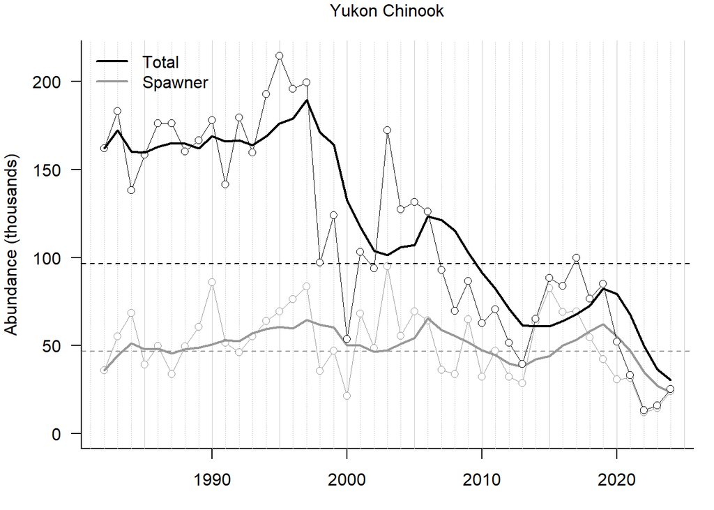

**Above:**Spawner abundance (grey) and total abundance (black) of Yukon River Chinook salmon. For both, the raw data is shown by points and the smoothed metric by solid lines. Dashed horizonal lines represent the long-term average for each.

```r
# Load data ---
ytck <- read.csv('../data/yukon_chinook_appendixB11.csv')
# Note: Use Run Reconstruction (RR) estimates of spawning escapement and total
# run size, not "Historical" or Mark-Recapture estimates

# Check if years are continuous
#unique(diff(ytck$Year)) # Yes, all one year apart # commented out to avoid outputting in Rmd

# Reformat data for SPS ---
ytck_sps <- data.frame(
    region = rep("Yukon", dim(ytck)[1]),
    species = rep("Chinook", dim(ytck)[1]),
    year = ytck$Year,
    spawners = ytck$RR.Spawning.escapement.estimate,
    smoothedSpawners = NA,
    runsize = ytck$RR.Canadian.origin.total.run.size.estimate,
    smoothedRunsize = NA,
    source_id = rep("JTC_202503", dim(ytck)[1])
)

# Smoothing
ytck_sps$smoothedSpawners <- genSmooth(
    abund = ytck_sps$spawners,
    years = ytck_sps$year,
    genLength = genLength$gen_length[genLength$region == "Yukon" & genLength$species == "Chinook"]
    )

ytck_sps$smoothedRunsize <- genSmooth(
    abund = ytck_sps$runsize,
    years = ytck_sps$year,
    genLength = genLength$gen_length[genLength$region == "Yukon" & genLength$species == "Chinook"]
)

# Add to SPS data
sps_data <- rbind(sps_data, ytck_sps)

# Generate standard plot
plot_abund(ytck_sps)
```

#### Chum

Canadian-origin fall chum spawner abundance was taken as the `Spawning escapement estimate` in Appendix B16 and total abundance as the `Total estimated Canadian-origin run size` from Appendix B20 of Yukon River Joint Technical Committee (2025).

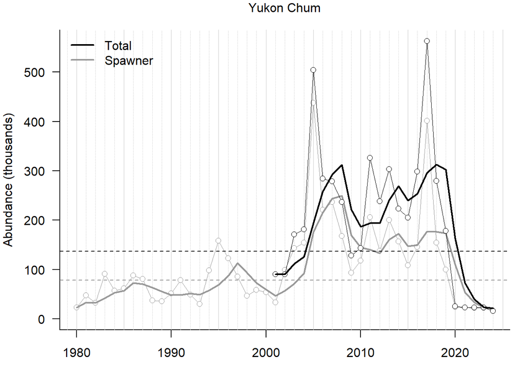

**Above:**Spawner abundance (grey) and total abundance (black) of Yukon River chum salmon. For both, the raw data is shown by points and the smoothed metric by solid lines. Dashed horizonal lines represent the long-term average for each.

```r
# Load data ---
ytcm_B16 <- read.csv('../data/yukon_chum_appendixB16.csv') # Historical data
names(ytcm_B16)[1] <- "Year"
ytcm_B20 <- read.csv('../data/yukon_chum_appendixB20.csv') # Most recent estimates

# Check if years are continuous
#unique(diff(ytcm_B16$Year)) # Yes, all one year apart
#unique(diff(ytcm_B20$Year)) # Yes, all one year apart

# Reformat data for SPS
ytcm_sps <- data.frame(
    region = rep("Yukon", dim(ytcm_B16)[1]),
    species = rep("Chum", dim(ytcm_B16)[1]),
    year = ytcm_B16$Year,
    spawners = ytcm_B16$Spawning.escapement.estimate,
    smoothedSpawners = NA,
    runsize = ytcm_B20$Total.estimated.Canadian.origin.run.size[match(ytcm_B16$Year, ytcm_B20$Year)],
    smoothedRunsize = NA,
    source_id = rep("JTC_202503", dim(ytcm_B16)[1])
)

# Smoothing
ytcm_sps$smoothedSpawners <- genSmooth(
    abund = ytcm_sps$spawners,
    years = ytcm_sps$year,
    genLength = genLength$gen_length[genLength$region == "Yukon" & genLength$species == "Chum"]
)

ytcm_sps$smoothedRunsize <- genSmooth(
    abund = ytcm_sps$runsize,
    years = ytcm_sps$year,
    genLength = genLength$gen_length[genLength$region == "Yukon" & genLength$species == "Chum"]
)

# Add to SPS data
sps_data <- rbind(sps_data, ytcm_sps)

# Generate standard plot
plot_abund(ytcm_sps)
```

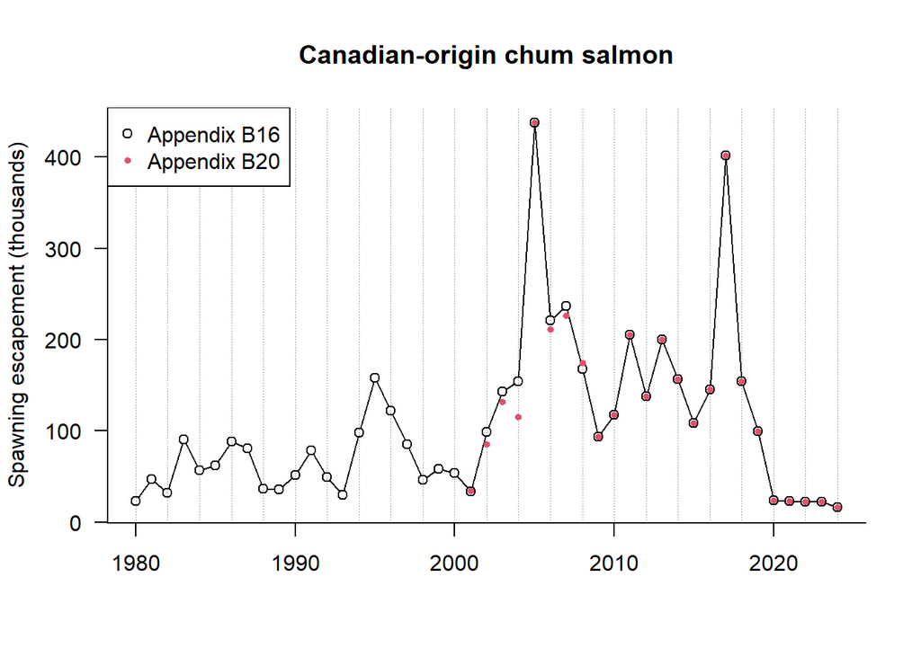

**Above:**Comparison of spawning escapement data from two sources in the Yukon River Joint Technical Committee documentation. We use the spawning escapement from Appendix B16 for our spawning escapement metric, while the escapement data from Appendix B20 makes up part of the total abundance metric we use.

```r
# Compare data from two appendices; note that spawning escapement is sometimes different
plot(ytcm_B16$Year, ytcm_B16$Spawning.escapement.estimate*10^-3, "o", ylab = "Spawning escapement (thousands)", las = 1, bty = "l", xlab = "", pch = 21, bg = "white", main = "Canadian-origin chum salmon")
abline(v = seq(1970, 2024, 2), col = "#00000060", lwd = 0.8, lty = 3)
points(ytcm_B20$Year, ytcm_B20$Spawning.escapement*10^-3, col = 2, pch = 19, cex = 0.6)
legend("topleft", pch= c(1, 19), pt.cex = c(1, 0.6), col = c(1,2), c("Appendix B16", "Appendix B20"))
```

### 2.2.2 Northern Transboundary

The best-available information on salmon abundance in the Northern Transboundary region is from the PSC’s [Joint Transboundary Technical Committee Reports](https://www.psc.org/publications/technical-reports/technical-committee-reports/transboundary/). The most recent TTC report (Transboundary Technical Committee 2022) includes data through 2021. Updated report appendices were provided by Aaron Foos (DFO) on April 15, 2025 in advance of report publication, and numbers for 2023 and 2024 should be considered **preliminary**.

We recognize that our approach in the Transboundary lacks information from many un-monitored watersheds, in particular the smaller watersheds of the Chilkat, Unuk, and Whiting Rivers. In the absence of better monitoring, we choose to report available data as a proxy for regional abundance, and note that the contribution of these smaller watersheds to total regional abundance for each species is likely small.

#### Chinook

The regional spawner abundance and total return of Chinook was calculated as the sum of escapement and total return, respectively, to the Stikine, Alsek, and Taku indicator stocks. For each of these stocks, we used escapement and exploitation rates provided by the [PSC’s Chinook Technical Committee](https://www.psc.org/publications/technical-reports/technical-committee-reports/chinook/) as part of their Synoptic Evaluations of Stock Status. These data were downloaded from their [Data Application](https://psc1.shinyapps.io/ctc-shiny-app/_w_efbbad27/). Total abundance was calculated from the escapement, $E$, and exploitation rate, $r$, as $E/(1-r)$.

At the time of publication, the Synoptic Evaluations of Stock Status were not yet available for 2024 so we used the escapement estimates for Stikine, Alsek, and Taku Chinook from Table B2 of Appendix B - Detailed Escapement, available as a downloadable dataset from the [Chinook Technical Committee](https://www.psc.org/publications/technical-reports/technical-committee-reports/chinook/ctc-data-sets/). Canadian and US harvest of Chinook was provided by Aaron Foos (DFO) as updated tables from the Transboundary Technical Committee report. Specifically, harvest for Stikine Chinook from Table B12 and harvest of Taku Chinook from Table D8. Total harvest of Alsek Chinook was 235, provided by Teresa Wallace (DFO, pers. comm.): US Commercial: 187, US Subsistence: 8, CAN (Aboriginal): 40, CAN Recreational: 0 (No CAN recreational harvest permitted in 2024).

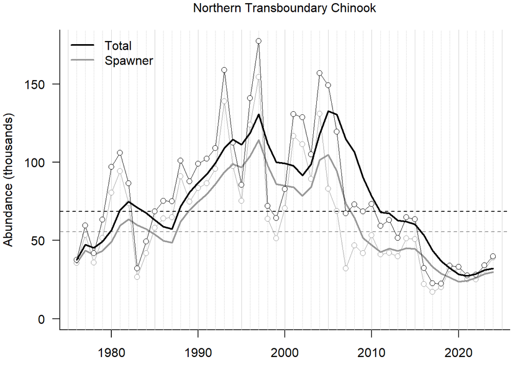

**Above:**Spawner abundance (grey) and total abundance (black) of Transboundary chinook salmon. For both, the raw data is shown by points and the smoothed metric by solid lines. Dashed horizonal lines represent the long-term average for each.

```r
# Load data ---
tbrck_raw <- read.csv("../data/CTC_Synoptic_evaluation_data_all_2025-04-16.csv") %>%
    filter(Year > 1975) %>% # Remove 1975 -> missing Alsek data
    filter(Stock %in% c("Alsek", "Taku", "Stikine")) %>%
    dplyr::select(Stock, Year, Escapement, RateType, Rate) %>%
    mutate(TotalRun = Escapement/(1 - Rate))

tbrck_esc <- readxl::read_xlsx("../data/TCCHINOOK-25-02-Appendix-B-Escapement-Detailed.xlsx", sheet = "B2", range = "A5:G53", col_names = c("year", "Alsek_esc", "Alsek_cv", "Taku_esc", "Taku_cv", "Stikine_esc", "Stikine_cv"))
# Ignore 1975 because not available for Alsek

# For 2024, take harvest from TTC B12, D8, Alsek harvest provided by email (Teresa Wallace, DFO)
tbrck <- tbrck_raw %>%
    group_by(Year) %>%
    summarise(Escapement_all = sum(Escapement),
                        TotalRun_all = sum(TotalRun),
                        source_id = "PSC_20250416") %>%
    bind_rows(data.frame(Year = 2024,
                        Escapement_all = (tbrck_esc$Alsek_esc + tbrck_esc$Taku_esc + tbrck_esc$Stikine_esc)[tbrck_esc$year == 2024],
                        TotalRun_all = 717 + (tbrck_esc$Alsek_esc + tbrck_esc$Taku_esc + tbrck_esc$Stikine_esc)[tbrck_esc$year == 2024], source_id = "Foos_20250415"))

# Reformat data for SPS
tbrck_sps <- data.frame(
    region = rep("Northern Transboundary", length(tbrck$Year)),
    species = rep("Chinook", length(tbrck$Year)),
    year = tbrck$Year,
    spawners = tbrck$Escapement_all,
    smoothedSpawners = NA,
    runsize = tbrck$TotalRun_all,
    smoothedRunsize = NA,
    source_id = tbrck$source_id
)

# Smoothing
tbrck_sps$smoothedSpawners <- genSmooth(
    abund = tbrck_sps$spawners,
    years = tbrck_sps$year,
    genLength = genLength$gen_length[genLength$region == "Northern Transboundary" & genLength$species == "Chinook"]
)

tbrck_sps$smoothedRunsize <- genSmooth(
    abund = tbrck_sps$runsize,
    years = tbrck_sps$year,
    genLength = genLength$gen_length[genLength$region == "Northern Transboundary" & genLength$species == "Chinook"]
)

plot_abund(tbrck_sps)
```

```r
# Add to master sps dataframe
sps_data <- rbind(sps_data, tbrck_sps)
```

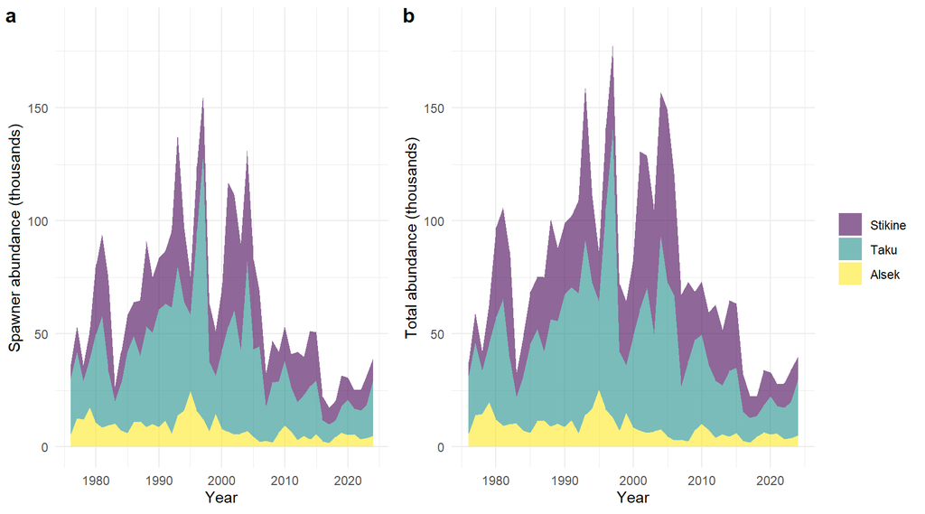

**Above:** (a) Chinook salmon spawner abundance and (b) total abundance showing the contributions of the Alsek, Taku, and Stikine river basins.

#### Sockeye and Coho

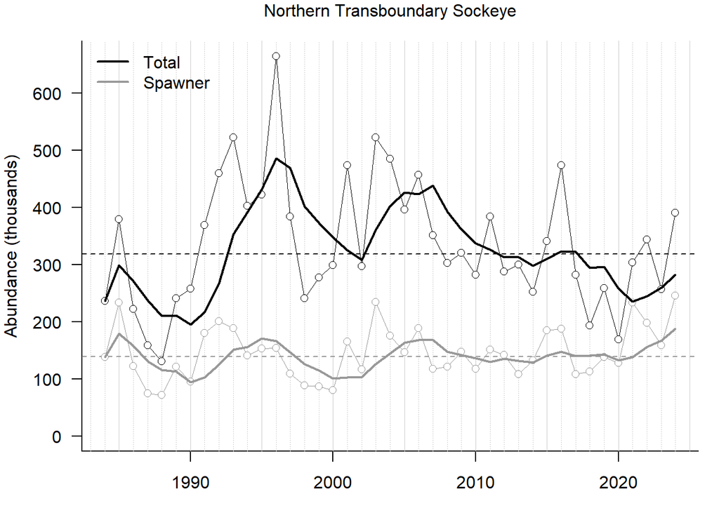

**Above:**Spawner abundance (grey) and total abundance (black) of Transboundary sockeye salmon. For both, the raw data is shown by points and the smoothed metric by solid lines. Dashed horizonal lines represent the long-term average for each.

```r
# TBR Sockeye data are the sum of the Stikine (Appendix B26) and Taku (Appendix D17)
# In 2024, the Appendix numbers given were B21 and D15 respectively, but that's changed.
tbrse_stik <- read.csv('../data/tbr_sockeye_appendixB26.csv')
tbrse_taku <- read.csv('../data/tbr_sockeye_appendixD17.csv')

# Remove Stikine data prior to 1984
tbrse_stik <- subset(tbrse_stik, tbrse_stik$Year >= 1984)

# Reformat data for SPS
tbrse_sps <- data.frame(
    region = rep("Northern Transboundary", dim(tbrse_stik)[1]),
    species = rep("Sockeye", dim(tbrse_stik)[1]),
    year = tbrse_stik$Year,
    spawners = tbrse_stik$StikineRiver_EscapementBroodstock + tbrse_taku$Escapement,
    smoothedSpawners = NA,
    runsize = tbrse_stik$StikineRiver_TerminalRun + tbrse_taku$Run,
    smoothedRunsize = NA,
    source_id = rep("Foos_20250415", dim(tbrse_stik)[1])
)

# Smoothing
tbrse_sps$smoothedSpawners <- genSmooth(
    abund = tbrse_sps$spawners,
    years = tbrse_sps$year,
    genLength = genLength$gen_length[genLength$region == "Northern Transboundary" & genLength$species == "Sockeye"]
)

tbrse_sps$smoothedRunsize <- genSmooth(
    abund = tbrse_sps$runsize,
    years = tbrse_sps$year,
    genLength = genLength$gen_length[genLength$region == "Northern Transboundary" & genLength$species == "Sockeye"]
)

# Add to master sps dataframe
sps_data <- rbind(sps_data, tbrse_sps)

# Generate standard plot
plot_abund(tbrse_sps)
```

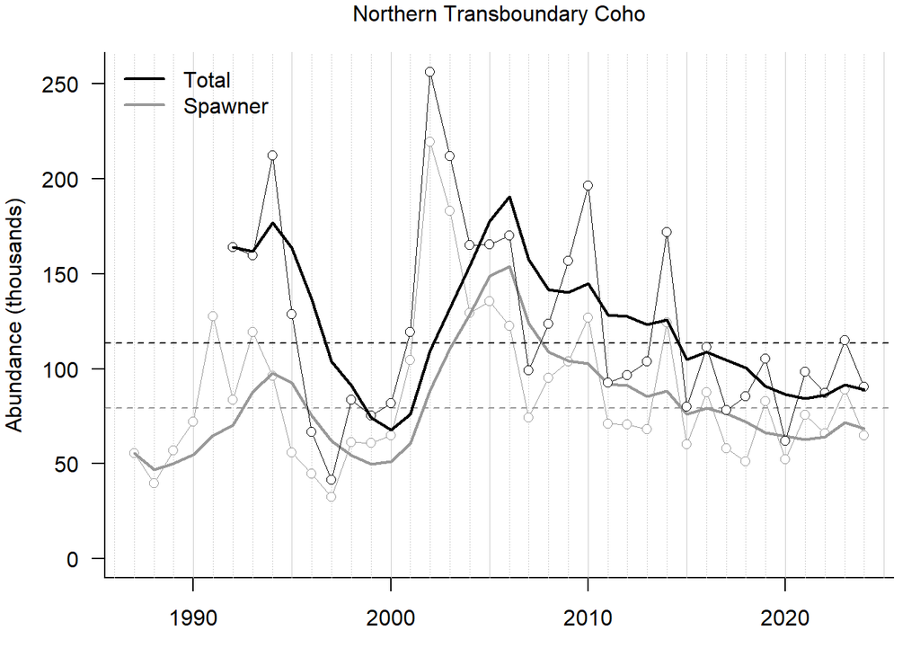

**Above:**Spawner abundance (grey) and total abundance (black) of Transboundary coho salmon. For both, the raw data is shown by points and the smoothed metric by solid lines. Dashed horizonal lines represent the long-term average for each.

```r
# Load data ---

tbrco <- read.csv('../data/tbr_coho_appendixD22.csv')

# Check if years are continuous
#unique(diff(tbrco$Year)) # Yes, all one year apart

# Reformat data for SPS
tbrco_sps <- data.frame(
    region = rep("Northern Transboundary", dim(tbrco)[1]),
    species = rep("Coho", dim(tbrco)[1]),
    year = tbrco$Year,
    spawners = tbrco$Escapement,
    smoothedSpawners = NA,
    runsize = tbrco$TerminalRun,
    smoothedRunsize = NA,
    source_id = rep("Foos_20250415", dim(tbrco)[1])
)

# Smoothing
tbrco_sps$smoothedSpawners <- genSmooth(
    abund = tbrco_sps$spawners,
    years = tbrco_sps$year,
    genLength = genLength$gen_length[genLength$region == "Northern Transboundary" & genLength$species == "Coho"]
)

tbrco_sps$smoothedRunsize <- genSmooth(
    abund = tbrco_sps$runsize,
    years = tbrco_sps$year,
    genLength = genLength$gen_length[genLength$region == "Northern Transboundary" & genLength$species == "Coho"]
)

# Add to master sps dataframe
sps_data <- rbind(sps_data, tbrco_sps)

# Generate standard plot
plot_abund(tbrco_sps)
```

#### Pink and Chum

Monitoring of pink and chum salmon in the Transboundary region is limited, and the best available information is the Canyon Island fish wheel on the Taku River.

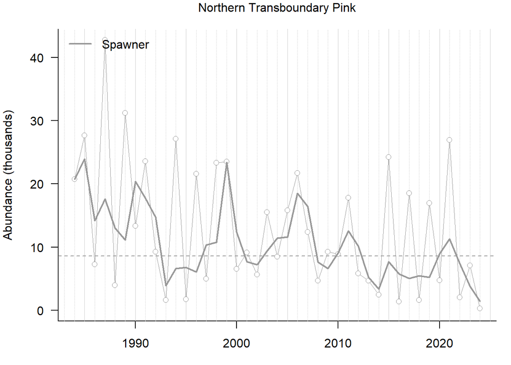

**Above:**Spawner abundance of Transboundary pink salmon. The raw data is shown by points and the smoothed metric by solid lines. Dashed horizonal lines represent the long-term average.

```r
# Load data ---
tbrpk <- read.csv("../data/TTC_ManualExtract_Taku_Pink.csv") %>%
    filter(!is.na(Value))

# Check if years are continuous
#unique(diff(tbrpk$Year)) # Yes, all one year apart

# Reformat data for SPS
tbrpk_sps <- data.frame(
    region = rep("Northern Transboundary", nrow(tbrpk)),
    species = rep("Pink", nrow(tbrpk)),
    year = tbrpk$Year,
    spawners = tbrpk$Value,
    smoothedSpawners = NA,
    runsize = NA,
    smoothedRunsize = NA,
    source_id = rep("Foos_20250415", nrow(tbrpk))
)
# Smoothing
tbrpk_sps$smoothedSpawners <- genSmooth(
    abund = tbrpk_sps$spawners,
    years = tbrpk_sps$year,
    genLength = genLength$gen_length[genLength$region == "Northern Transboundary" & genLength$species == "Pink"]
)

# Add to master sps dataframe
sps_data <- rbind(sps_data, tbrpk_sps)

# Generate standard plot
plot_abund(tbrpk_sps)
```

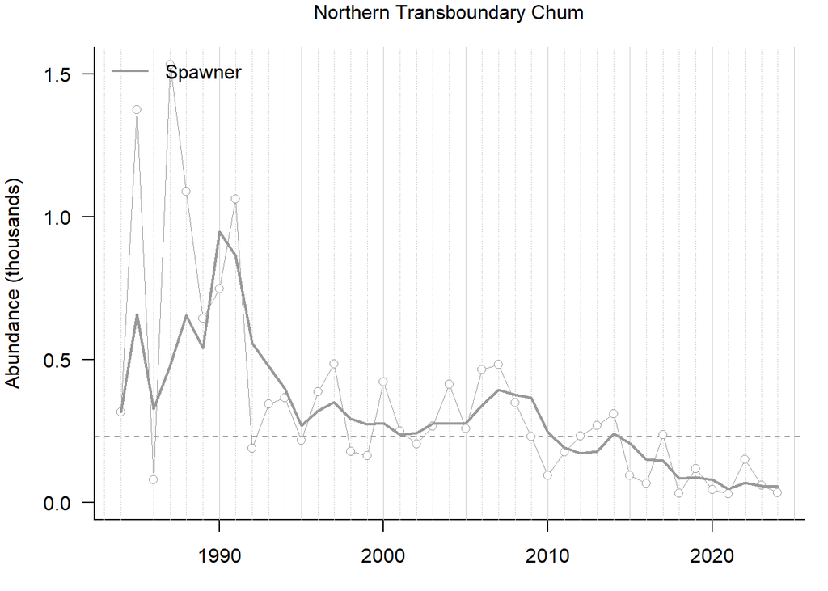

**Above:**Spawner abundance of Transboundary chum salmon. The raw data is shown by points and the smoothed metric by solid lines. Dashed horizonal lines represent the long-term average.

```r
# Load data ---
tbrcm <- read.csv("../data/TTC_ManualExtract_Taku_Chum.csv") %>%
    filter(!is.na(Value))

# Reformat data for SPS
tbrcm_sps <- data.frame(
    region = rep("Northern Transboundary", nrow(tbrcm)), #length(which(tbrpkcm$species_pooled == "Chum"))),
    species = rep("Chum", nrow(tbrcm)), #length(which(tbrpkcm$species_pooled == "Chum"))),
    year = tbrcm$Year, #sort(tbrpkcm$year[tbrpkcm$species_pooled == "Chum"]),
    spawners = tbrcm$Value, #tbrpkcm$stream_observed_count[tbrpkcm$species_pooled == "Chum"][order(tbrpkcm$year[tbrpkcm$species_pooled == "Chum"])],
    smoothedSpawners = NA,
    runsize = NA,
    smoothedRunsize = NA,
    source_id = rep("Foos_20250415", nrow(tbrcm))
)
# Smoothing
tbrcm_sps$smoothedSpawners <- genSmooth(
    abund = tbrcm_sps$spawners,
    years = tbrcm_sps$year,
    genLength = genLength$gen_length[genLength$region == "Northern Transboundary" & genLength$species == "Chum"]
)

# Add to master sps dataframe
sps_data <- rbind(sps_data, tbrcm_sps)

# Generate standard plot
plot_abund(tbrcm_sps)
```

#### Steelhead

Steelhead trout have also been enumerated at the Canyon Island fish wheel since 1987, though recent estimates have been patchy and the timing of the fish wheel likely misses a substantial portion of the Taku summer run steelhead. Thus, we do not use the Canyon Island counts.

### 2.2.3 Haida Gwaii

#### Chinook

The only available data for Chinook salmon in Haida Gwaii are from a single enumeration project on the Yakoun River. Although monitoring on the Yakoun has recently been restored, the most recent estimate for Yakoun Chinook that is publicly available is from 2006. We show Yakoun River spawner abundance up to 2006, but no estimates were available for the most recent generation making the current status for Haida Gwaii Chinook “Unknown”.

These estimates also match the estimated escapement to Area 1 in the Northern Boundary Technical Committee (2023) (Appendix 30).

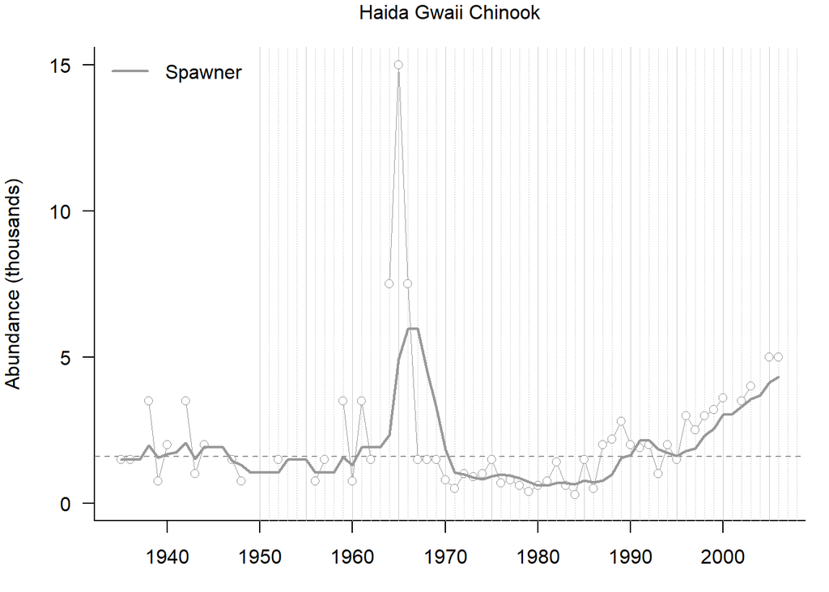

**Above:**Spawner abundance of Haida Gwaii chinook salmon. The raw data is shown by points and the smoothed metric by solid lines. Dashed horizonal lines represent the long-term average.

```r
# No recent data, but at least show what we have for Yakoun
# These are consistent with the TCNB escapement data for Area 1 (Table 30)

hgck <- read.csv("../data/spawner_surveys.csv", na.strings = c(-989898)) %>%
    subset(species_name == "Chinook" & region == "Haida Gwaii") %>%
    subset(stream_name_pse == "YAKOUN RIVER")

# There are some missing years of data; want to impute in between when smoothing
#diff(hgck$year)
hgck_years <- min(hgck$year):max(hgck$year)

# Reformat data for SPS
hgck_sps <- data.frame(
    region = rep("Haida Gwaii", length(hgck_years)),
    species = rep("Chinook", length(hgck_years)),
    year = hgck_years,
    spawners = hgck$stream_observed_count[match(hgck_years, hgck$year)],
    smoothedSpawners = NA,
    runsize = NA,
    smoothedRunsize = NA,
    source_id = rep(nuseds_id, length(hgck_years))
)

# Smoothing
hgck_sps$smoothedSpawners <- genSmooth(
    abund = hgck_sps$spawners,
    years = hgck_sps$year,
    genLength = genLength$gen_length[genLength$region == "Haida Gwaii" & genLength$species == "Chinook"]
)

# Add to master sps dataframe
sps_data <- rbind(sps_data, hgck_sps)

# Generate standard plot
plot_abund(hgck_sps)
```

#### Chum

For chum, coho, pink, and sockeye in Haida Gwaii, we followed the Expansion Factors approach described below. We compared our expansion approach to estimates of Area 1 escapement as reported in the Northern Boundary Technical Committee (2023) (Appendix 30), but found the Area 1 estimates were much lower for chum (see “alternate” series in figure below).

```r
# Load data ---
region_spawners <- sp <- readRDS("../output/expanded-spawners/Haida Gwaii-spawners.rds")
yrs <- as.numeric(dimnames(sp)[[3]])
expansion_factors <- readRDS("../output/expanded-spawners/Haida Gwaii-expansion-factors.rds")

# PSC Northern Boundary data (Appendix 30) for comparison
hg_table30 <- read.csv("../data/TCNB-23-01_Table30_Area1escapement.csv")
names(hg_table30) <- c("year", "Sockeye", "Coho", "Pink", "Chum", "Chinook") # Change names to be consistent with species
```

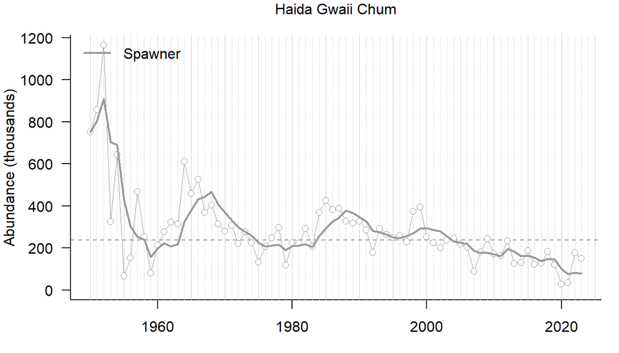

**Above:** Spawner abundance of Haida Gwaii chum salmon. The raw data is shown by points and the smoothed metric by solid lines. Dashed horizonal lines represent the long-term average.

```r
# Data loaded above
hg.s <- sp[2, "Chum", ]

# Reformat data for SPS
hg.s_sps <- data.frame(
    region = rep("Haida Gwaii", length(hg.s)),
    species = rep("Chum", length(hg.s)),
    year = as.numeric(names(hg.s)),
    spawners = as.numeric(hg.s),
    smoothedSpawners = NA,
    runsize = NA,
    smoothedRunsize = NA,
    source_id = rep(nuseds_id, length(hg.s))
)

# Smoothing
hg.s_sps$smoothedSpawners <- genSmooth(
    abund = hg.s_sps$spawners,
    years = hg.s_sps$year,
    genLength = genLength$gen_length[genLength$region == "Haida Gwaii" & genLength$species == "Chum"]
)

# Add to master sps dataframe
sps_data <- rbind(sps_data, hg.s_sps)

# Generate standard figure
plot_abund(hg.s_sps)
```

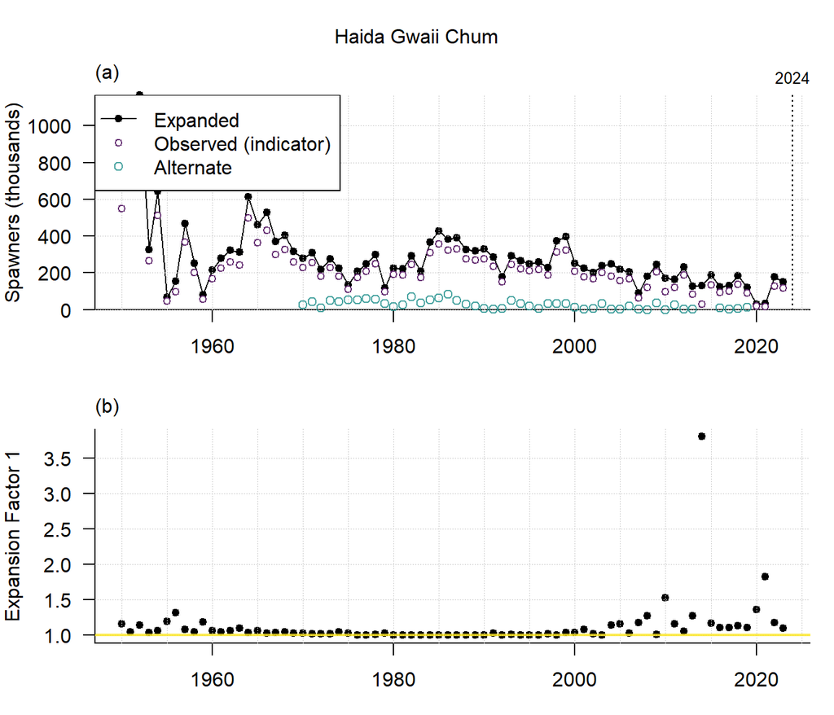

**Above:** (a) Time series of spawner abundances showing raw sum of counts for indicator streams (purple) and expanded estimates of spawner abudnance to indicator and non-indicator streams (black). This expanded time series is what is used to assess the current state and trends in spawner abundance for the region and species. Alternative time series from the PSC’s Northern Boundary Technical Committee Report (Appendix 30) is shown in blue. (b) The values of Expansion Factor 1 that accounts for unmonitored indicator streams in a given year, and is calculated based on the proportional contribution of the unmonitored indicator stream(s) to the sum of all indicator streams in a (reference) decade. See section on Expansion Factors below for further details.

```r
# Additional series to plot
added_series.s <- hg_table30 %>%
        select(year, "Chum") %>%
        rename("value" = "Chum")

# Expansion plot(s)
plot_expansions(speciesname = "Chum",
                                regionname = "Haida Gwaii",
                                region_spawners = region_spawners,
                                expansion_factors = expansion_factors,
                                added_series = added_series.s)
```

#### Coho

For chum, coho, pink, and sockeye in Haida Gwaii, we followed the Expansion Factors approach described below. We compared our expansion approach to estimates of escapement to Area 1 reported in the Northern Boundary Technical Committee (2023) (Appendix 30) but found the Area 1 estimates were much lower for coho.

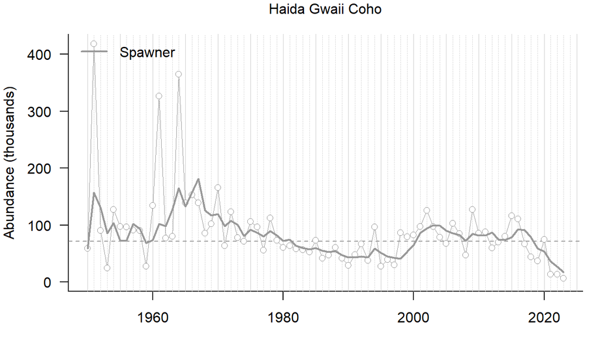

**Above:** Spawner abundance of Haida Gwaii coho salmon. The raw data is shown by points and the smoothed metric by solid lines. Dashed horizonal lines represent the long-term average.

```r
# Data loaded above
hg.s <- sp[2, "Coho", ]

# Reformat data for SPS
hg.s_sps <- data.frame(
    region = rep("Haida Gwaii", length(hg.s)),
    species = rep("Coho", length(hg.s)),
    year = as.numeric(names(hg.s)),
    spawners = as.numeric(hg.s),
    smoothedSpawners = NA,
    runsize = NA,
    smoothedRunsize = NA,
    source_id = rep(nuseds_id, length(hg.s))
)

# Smoothing
hg.s_sps$smoothedSpawners <- genSmooth(
    abund = hg.s_sps$spawners,
    years = hg.s_sps$year,
    genLength = genLength$gen_length[genLength$region == "Haida Gwaii" & genLength$species == "Coho"]
)

# Add to master sps dataframe
sps_data <- rbind(sps_data, hg.s_sps)

# Generate standard figure
plot_abund(hg.s_sps)
```

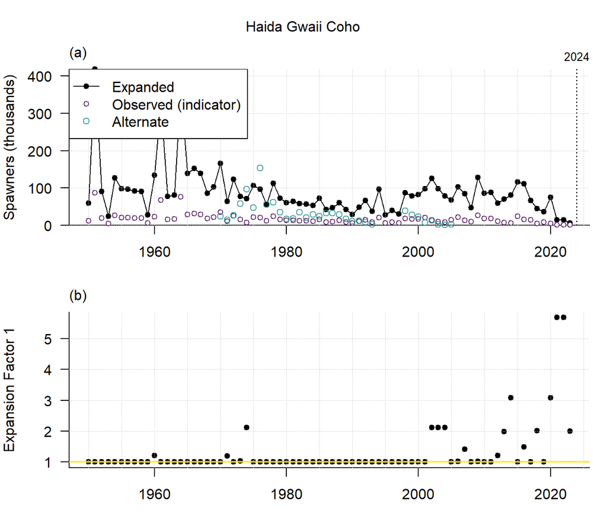

**Above:** (a) Time series of spawner abundances showing raw sum of counts for indicator streams (purple) and expanded estimates of spawner abudnance to indicator and non-indicator streams (black). This expanded time series is what is used to assess the current state and trends in spawner abundance for the region and species. Alternative time series from the PSC’s Northern Boundary Technical Committee Report (Appendix 30) is shown in blue. (b) The values of Expansion Factor 1 that accounts for unmonitored indicator streams in a given year, and is calculated based on the proportional contribution of the unmonitored indicator stream(s) to the sum of all indicator streams in a (reference) decade. See section on Expansion Factors below for further details.

```r
# Additional series to plot
added_series.s <- hg_table30 %>%
        select(year, "Coho") %>%
        rename("value" = "Coho")

# Expansion plot(s)
plot_expansions(speciesname = "Coho",
                                regionname = "Haida Gwaii",
                                region_spawners = region_spawners,
                                expansion_factors = expansion_factors,
                                added_series = added_series.s)
```

#### Pink

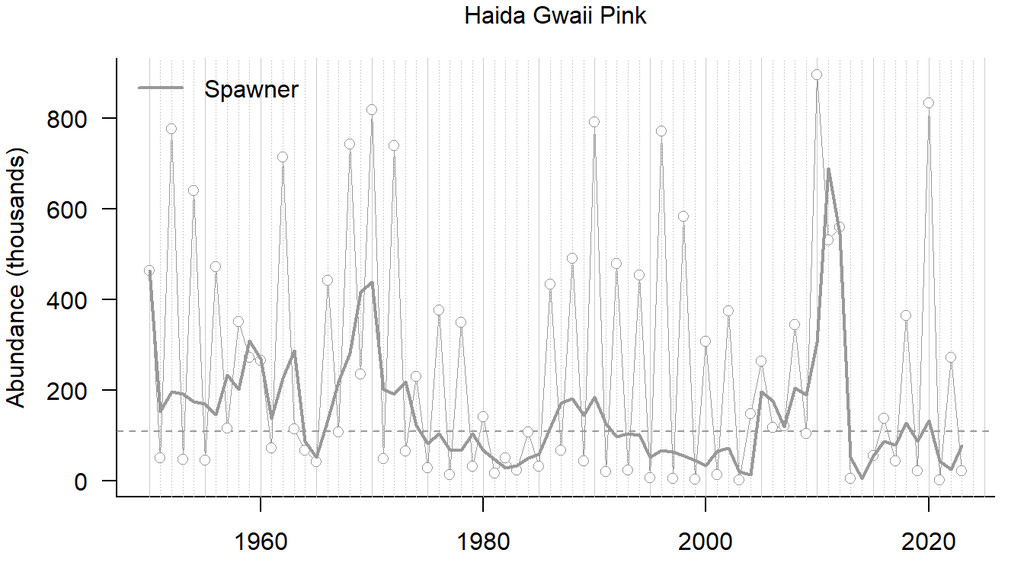

**Above:** Spawner abundance of Haida Gwaii pink salmon. The raw data is shown by points and the smoothed metric by solid lines. Dashed horizonal lines represent the long-term average.

```r
# Data loaded above
hg.s <- sp[2, "Pink", ]

# Reformat data for SPS
hg.s_sps <- data.frame(
    region = rep("Haida Gwaii", length(hg.s)),
    species = rep("Pink", length(hg.s)),
    year = as.numeric(names(hg.s)),
    spawners = as.numeric(hg.s),
    smoothedSpawners = NA,
    runsize = NA,
    smoothedRunsize = NA,
    source_id = rep(nuseds_id, length(hg.s))
)

# Smoothing
hg.s_sps$smoothedSpawners <- genSmooth(
    abund = hg.s_sps$spawners,
    years = hg.s_sps$year,
    genLength = genLength$gen_length[genLength$region == "Haida Gwaii" & genLength$species == "Pink"]
)

# Add to master sps dataframe
sps_data <- rbind(sps_data, hg.s_sps)

# Generate standard figure
plot_abund(hg.s_sps)
```

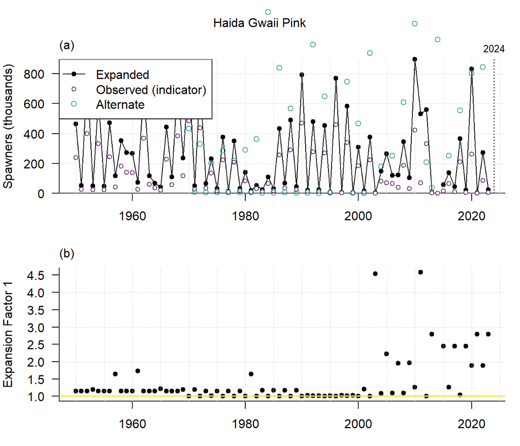

**Above:** (a) Time series of spawner abundances showing raw sum of counts for indicator streams (purple) and expanded estimates of spawner abudnance to indicator and non-indicator streams (black). This expanded time series is what is used to assess the current state and trends in spawner abundance for the region and species. Alternative time series from the PSC’s Northern Boundary Technical Committee Report (Appendix 30) is shown in blue. (b) The values of Expansion Factor 1 that accounts for unmonitored indicator streams in a given year, and is calculated based on the proportional contribution of the unmonitored indicator stream(s) to the sum of all indicator streams in a (reference) decade. See section on Expansion Factors below for further details.

```r
# Additional series to plot
added_series.s <- hg_table30 %>%
        select(year, "Pink") %>%
        rename("value" = "Pink")

# Expansion plot(s)
plot_expansions(speciesname = "Pink",
                                regionname = "Haida Gwaii",
                                region_spawners = region_spawners,
                                expansion_factors = expansion_factors,
                                added_series = added_series.s)
```

#### Sockeye

For chum, coho, pink, and sockeye in Haida Gwaii, we followed the Expansion Factors approach described below. We compared our expansion approach to estimates of Area 1 escapement as reported in the Northern Boundary Technical Committee (2023) (Appendix 30), but found the Area 1 estimates were much lower for sockeye (see “alternate” series in figure below).

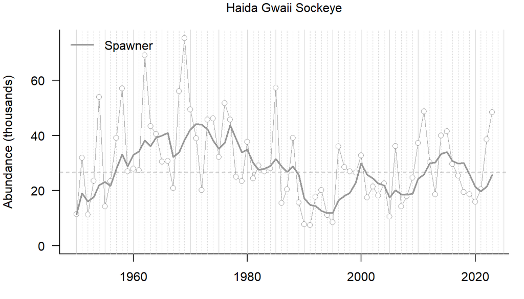

**Above:** Spawner abundance of Haida Gwaii sockeye salmon. The raw data is shown by points and the smoothed metric by solid lines. Dashed horizonal lines represent the long-term average.

```r
# Data loaded above
hg.s <- sp[2, "Sockeye", ]

# Reformat data for SPS
hg.s_sps <- data.frame(
    region = rep("Haida Gwaii", length(hg.s)),
    species = rep("Sockeye", length(hg.s)),
    year = as.numeric(names(hg.s)),
    spawners = as.numeric(hg.s),
    smoothedSpawners = NA,
    runsize = NA,
    smoothedRunsize = NA,
    source_id = rep(nuseds_id, length(hg.s))
)

# Smoothing
hg.s_sps$smoothedSpawners <- genSmooth(
    abund = hg.s_sps$spawners,
    years = hg.s_sps$year,
    genLength = genLength$gen_length[genLength$region == "Haida Gwaii" & genLength$species == "Sockeye"]
)

# Add to master sps dataframe
sps_data <- rbind(sps_data, hg.s_sps)

# Generate standard figure
plot_abund(hg.s_sps)
```

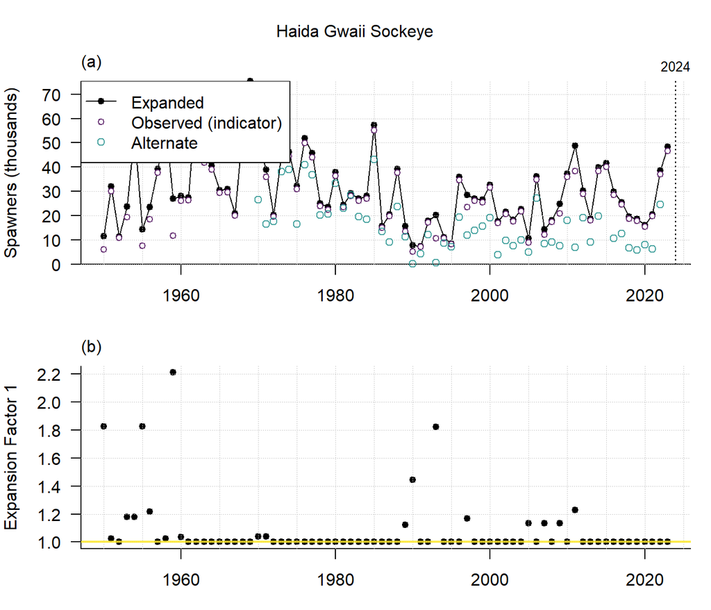

**Above:** (a) Time series of spawner abundances showing raw sum of counts for indicator streams (purple) and expanded estimates of spawner abudnance to indicator and non-indicator streams (black). This expanded time series is what is used to assess the current state and trends in spawner abundance for the region and species. Alternative time series from the PSC’s Northern Boundary Technical Committee Report (Appendix 30) is shown in blue. (b) The values of Expansion Factor 1 that accounts for unmonitored indicator streams in a given year, and is calculated based on the proportional contribution of the unmonitored indicator stream(s) to the sum of all indicator streams in a (reference) decade. See section on Expansion Factors below for further details.

```r
# Additional series to plot
added_series.s <- hg_table30 %>%
        select(year, "Sockeye") %>%
        rename("value" = "Sockeye")

# Expansion plot(s)
plot_expansions(speciesname = "Sockeye",
                                regionname = "Haida Gwaii",
                                region_spawners = region_spawners,
                                expansion_factors = expansion_factors,
                                added_series = added_series.s)
```

### 2.2.4 Nass

#### Chinook

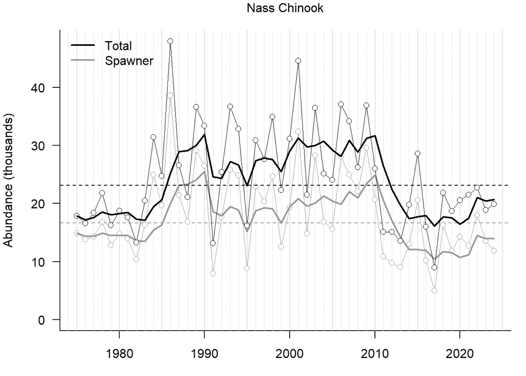

**Above:**Spawner abundance (grey) and total abundance (black) of Nass chinook salmon. For both, the raw data is shown by points and the smoothed metric by solid lines. Dashed horizonal lines represent the long-term average for each.

```r
# Load data ---
# TCCHINOOK Table B3
nass_ctc <- readxl::read_xlsx("../data/TCCHINOOK-25-02-Appendix-B-Escapement-Detailed.xlsx", sheet = "B3", range = "A5:D54", col_types = "numeric", col_names = c("Year", "Above_Gitwinksihlkw2", "Esc", "t.run"))

# Reformat data for SPS
nassck_sps <- data.frame(
    region = rep("Nass", length(nass_ctc$Year)),
    species = rep("Chinook", length(nass_ctc$Year)),
    year = nass_ctc$Year,
    spawners = nass_ctc$Esc,
    smoothedSpawners = NA,
    runsize = nass_ctc$t.run,
    smoothedRunsize = NA,
    source_id = rep(ctc_id, length(nass_ctc$Year))
)

# Smoothing
nassck_sps$smoothedSpawners <- genSmooth(
    abund = nassck_sps$spawners,
    years = nassck_sps$year,
    genLength = genLength$gen_length[genLength$region == "Nass" & genLength$species == "Chinook"]
)

nassck_sps$smoothedRunsize <- genSmooth(
    abund = nassck_sps$runsize,
    years = nassck_sps$year,
    genLength = genLength$gen_length[genLength$region == "Nass" & genLength$species == "Chinook"]
)

# Add to master sps dataframe
sps_data <- rbind(sps_data, nassck_sps)

# Generate standard plot
plot_abund(nassck_sps)
```

#### Sockeye

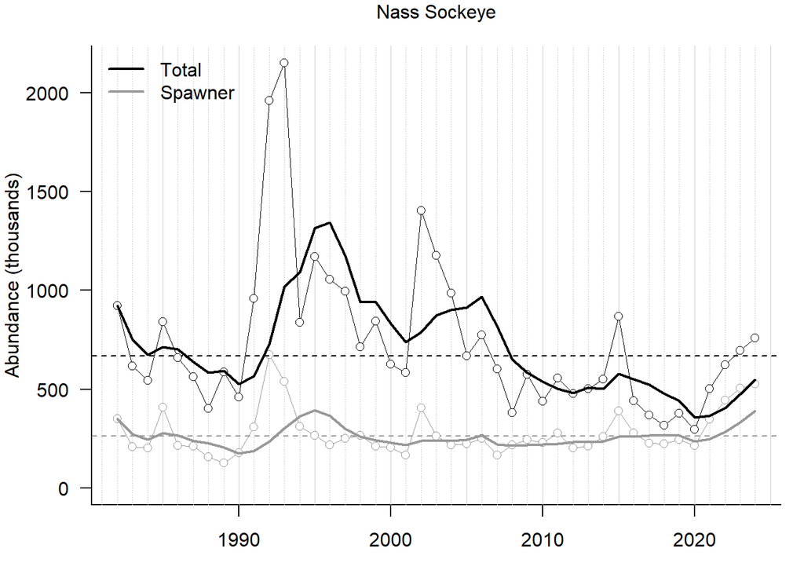

**Above:**Spawner abundance (grey) and total abundance (black) of Nass sockeye salmon. For both, the raw data is shown by points and the smoothed metric by solid lines. Dashed horizonal lines represent the long-term average for each.

```r
# Load Nisgaa data
nass_nisgaa <- read.csv("../data/2024NassStockAssessment_combinedTables19-21.csv")

# use NBSRR data provided by LGL up to 2022 and Nisga'a Post-season for 2023, 2024
nassse <- read.csv("../data/nassskeena_sockeye_lgl.csv") %>%
    subset(Region == "Nass") %>%
    mutate(source_id = "English_20230930") %>%
    bind_rows(
        data.frame(Year = c(2023, 2024),
                             TE = nass_nisgaa$ESC_Sockeye[nass_nisgaa$Year %in% c(2023, 2024)],
                             Total.Run = nass_nisgaa$TOTAL_RUN_Sockeye[nass_nisgaa$Year %in% c(2023, 2024)],
                             source_id = rep("Nisgaa_20241203", 2)
        )
    )


# Reformat data for SPS
nassse_sps <- data.frame(
    region = rep("Nass", dim(nassse)[1]),
    species = rep("Sockeye", dim(nassse)[1]),
    year = nassse$Year,
    spawners = nassse$TE,
    smoothedSpawners = NA,
    runsize = nassse$Total.Run,
    smoothedRunsize = NA,
    source_id = nassse$source_id
)

# Smoothing
nassse_sps$smoothedSpawners <- genSmooth(
    abund = nassse_sps$spawners,
    years = nassse_sps$year,
    genLength = genLength$gen_length[genLength$region == "Nass" & genLength$species == "Sockeye"]
)

nassse_sps$smoothedRunsize <- genSmooth(
    abund = nassse_sps$runsize,
    years = nassse_sps$year,
    genLength = genLength$gen_length[genLength$region == "Nass" & genLength$species == "Sockeye"]
)

# Add to master sps dataframe
sps_data <- rbind(sps_data, nassse_sps)

# Generate standard plot
plot_abund(nassse_sps)
```

#### Coho

Nass coho escapement and total return were available from the Nisga’a Fisheries and Wildlife Department (Nisga’a Fisheries and Wildlife Department (2024)) for 1992 to 2024. These data closely matched previous estimates from English et al. (2023) used in the 2024 report. Spawner surveys in NuSEDS tended to generally underestimate spawner abudnance to the region, and were not used because other data were available.

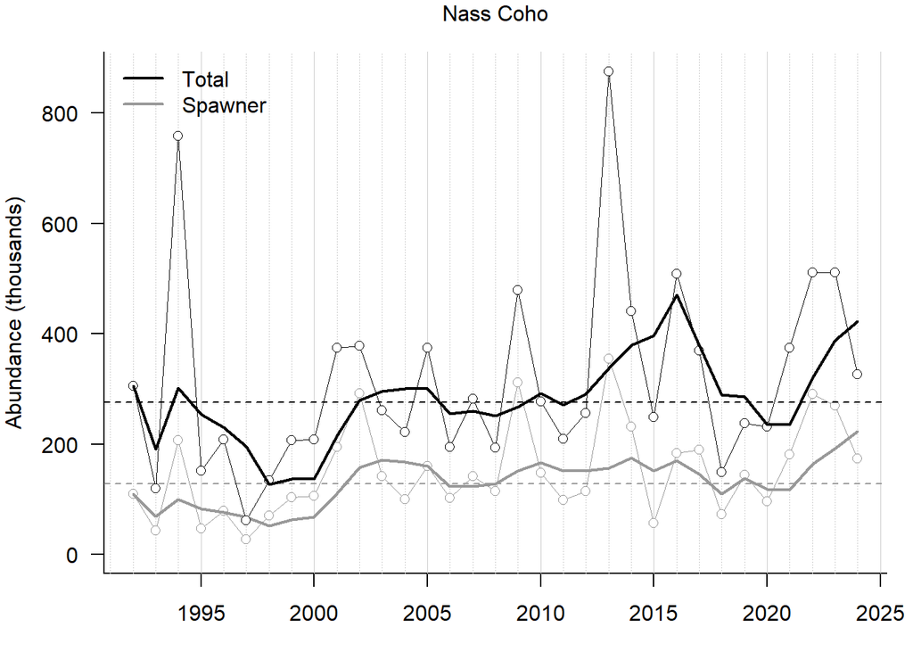

**Above:**Spawner abundance (grey) and total abundance (black) of Nass coho salmon. For both, the raw data is shown by points and the smoothed metric by solid lines. Dashed horizonal lines represent the long-term average for each.

```r
# Reformat data for SPS
nassco_sps <- data.frame(
    region = rep("Nass", length(nass_nisgaa$Year)),
    species = rep("Coho", length(nass_nisgaa$Year)),
    year = nass_nisgaa$Year,
    spawners = nass_nisgaa$ESC_Coho,
    smoothedSpawners = NA,
    runsize = nass_nisgaa$TOTAL_RUN_Coho,
    smoothedRunsize = NA,
    source_id = rep("Nisgaa_20241203",length(nass_nisgaa$Year))
)

# Smoothing
nassco_sps$smoothedSpawners <- genSmooth(
    abund = nassco_sps$spawners,
    years = nassco_sps$year,
    genLength = genLength$gen_length[genLength$region == "Nass" & genLength$species == "Coho"]
)

nassco_sps$smoothedRunsize <- genSmooth(
    abund = nassco_sps$runsize,
    years = nassco_sps$year,
    genLength = genLength$gen_length[genLength$region == "Nass" & genLength$species == "Coho"]
)

# Add to master sps dataframe
sps_data <- rbind(sps_data, nassco_sps)

# Generate standard plot
plot_abund(nassco_sps)
```

#### Pink and Chum

Chum and pink salmon spawner abundances were expanded from available spawner surveys from 1950 to 1991, as described below in Expansion Factors. Note that the designation of indicator streams for the Nass region was based on English et al. (2018) rather than the indicator designation in NuSEDS. From 1992 to 2024, estimates of spawner and total abundance were provided in the 2024 post-season report from the Nisga’a Fisheries and Wildlife Department (Nisga’a Fisheries and Wildlife Department (2024)).

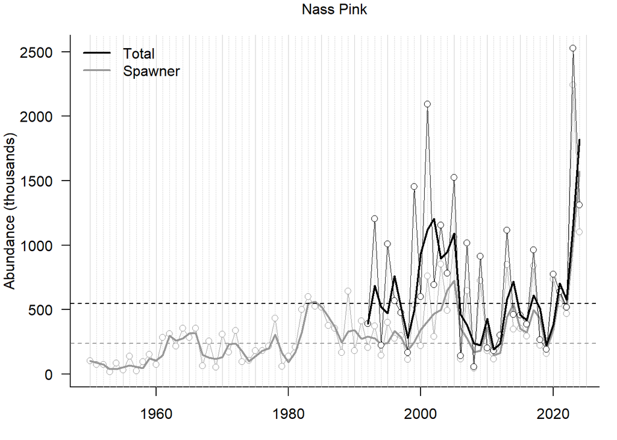

**Above:**Spawner abundance (grey) and total abundance (black) of Nass pink salmon. For both, the raw data is shown by points and the smoothed metric by solid lines. Dashed horizonal lines represent the long-term average for each.

```r
# Use expanded spawner abundance to 1991 then Nisga'a final report data
sp <- readRDS("../output/expanded-spawners/Nass-spawners.rds")
yrs <- as.numeric(dimnames(sp)[[3]])

nasspk <- data.frame(
    year = c(yrs, 2024),
    esc = c(round(sp["expanded", "Pink", which(yrs %in% c(1950:1991))]), nass_nisgaa$ESC_Pink),
    run = c(rep(NA, length(c(1950:1991))), nass_nisgaa$TOTAL_RUN_Pink),
    source_id = c(rep(nuseds_id, length(c(1950:1991))), rep("Nisgaa_20241203", length(nass_nisgaa$TOTAL_RUN_Pink)))
)

# Reformat data for SPS
nasspk_sps <- data.frame(
    region = rep("Nass", length(nasspk$year)),
    species = rep("Pink", length(nasspk$year)),
    year = nasspk$year,
    spawners = nasspk$esc,
    smoothedSpawners = NA,
    runsize = nasspk$run,
    smoothedRunsize = NA,
    source_id = nasspk$source_id
)

# Smoothing
nasspk_sps$smoothedSpawners <- genSmooth(
    abund = nasspk_sps$spawners,
    years = nasspk_sps$year,
    genLength = genLength$gen_length[genLength$region == "Nass" & genLength$species == "Pink"]
)

nasspk_sps$smoothedRunsize <- genSmooth(
    abund = nasspk_sps$runsize,
    years = nasspk_sps$year,
    genLength = genLength$gen_length[genLength$region == "Nass" & genLength$species == "Pink"]
)

# Add to master sps dataframe
sps_data <- rbind(sps_data, nasspk_sps)

# Generate standard figure
plot_abund(nasspk_sps)
```

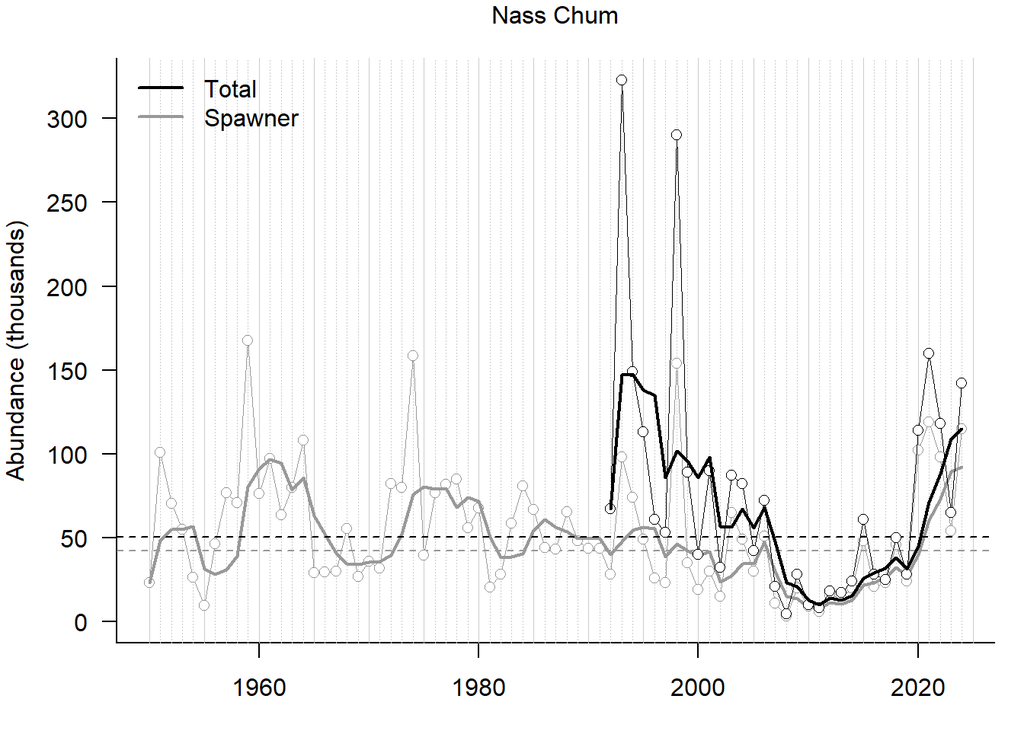

**Above:**Spawner abundance (grey) and total abundance (black) of Nass chum salmon. For both, the raw data is shown by points and the smoothed metric by solid lines. Dashed horizonal lines represent the long-term average for each.

```r
nasscm <- data.frame(
    year = c(yrs, 2024),
    esc = c(round(sp["expanded", "Chum", which(yrs %in% c(1950:1991))]), nass_nisgaa$ESC_Chum),
    run = c(rep(NA, length(c(1950:1991))), nass_nisgaa$TOTAL_RUN_Chum),
    source_id = c(rep(nuseds_id, length(c(1950:1991))), rep("Nisgaa_20241203", length(nass_nisgaa$TOTAL_RUN_Chum)))
)

# Reformat data for SPS
nasscm_sps <- data.frame(
    region = rep("Nass", length(nasscm$year)),
    species = rep("Chum", length(nasscm$year)),
    year = nasscm$year,
    spawners = nasscm$esc,
    smoothedSpawners = NA,
    runsize = nasscm$run,
    smoothedRunsize = NA,
    source_id = nasscm$source_id
)

# Smoothing
nasscm_sps$smoothedSpawners <- genSmooth(
    abund = nasscm_sps$spawners,
    years = nasscm_sps$year,
    genLength = genLength$gen_length[genLength$region == "Nass" & genLength$species == "Chum"]
)

nasscm_sps$smoothedRunsize <- genSmooth(
    abund = nasscm_sps$runsize,
    years = nasscm_sps$year,
    genLength = genLength$gen_length[genLength$region == "Nass" & genLength$species == "Chum"]
)

# Add to master sps dataframe
sps_data <- rbind(sps_data, nasscm_sps)

#Generate standard figure
plot_abund(nasscm_sps)
```

#### Steelhead

The index of Nass steelhead spawner abundance and total return are for the Nass Summer CU, developed in collaboration with the Nisga’a Fish and Wildlife Department and LGL Ltd. Nisga’a Fisheries and Wildlife Department (2024). There is another steelhead CU in the Nass region - Nass Winter - which is not well monitored and therefore not included in our index of spawner abundance.

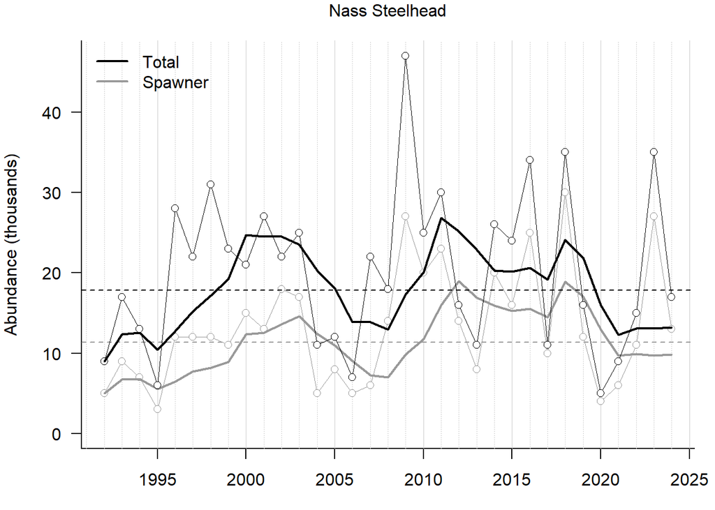

**Above:**Spawner abundance (grey) and total abundance (black) of Nass steelhead salmon. For both, the raw data is shown by points and the smoothed metric by solid lines. Dashed horizonal lines represent the long-term average for each.

```r
# Reformat data for SPS
nasssh_sps <- data.frame(
    region = rep("Nass", length(nass_nisgaa$Year)),
    species = rep("Steelhead", length(nass_nisgaa$Year)),
    year = nass_nisgaa$Year,
    spawners = nass_nisgaa$ESC_Steelhead,
    smoothedSpawners = NA,
    runsize = nass_nisgaa$TOTAL_RUN_Steelhead,
    smoothedRunsize = NA,
    source_id = rep("Nisgaa_20241203",length(nass_nisgaa$Year))
)

# Smoothing
nasssh_sps$smoothedSpawners <- genSmooth(
    abund = nasssh_sps$spawners,
    years = nasssh_sps$year,
    genLength = genLength$gen_length[genLength$region == "Nass" & genLength$species == "Steelhead"]
)

nasssh_sps$smoothedRunsize <- genSmooth(
    abund = nasssh_sps$runsize,
    years = nasssh_sps$year,
    genLength = genLength$gen_length[genLength$region == "Nass" & genLength$species == "Steelhead"]
)

# Add to master sps dataframe
sps_data <- rbind(sps_data, nasssh_sps)

# Generate standard figure
plot_abund(nasssh_sps)
```

### 2.2.5 Skeena

#### Chinook

Chinook spawners were taken from the [PSC’s Chinook Technical Committee (CTC) data sets](https://www.psc.org/publications/technical-reports/technical-committee-reports/chinook/ctc-data-sets/) and are reported on in Chinook Technical Committee (2025). Specifically, Skeena River (Area 4) escapement is provided in Table B3 (field `GSI esc`). There is no total return for the Skeena River provided in the CTC data sets.

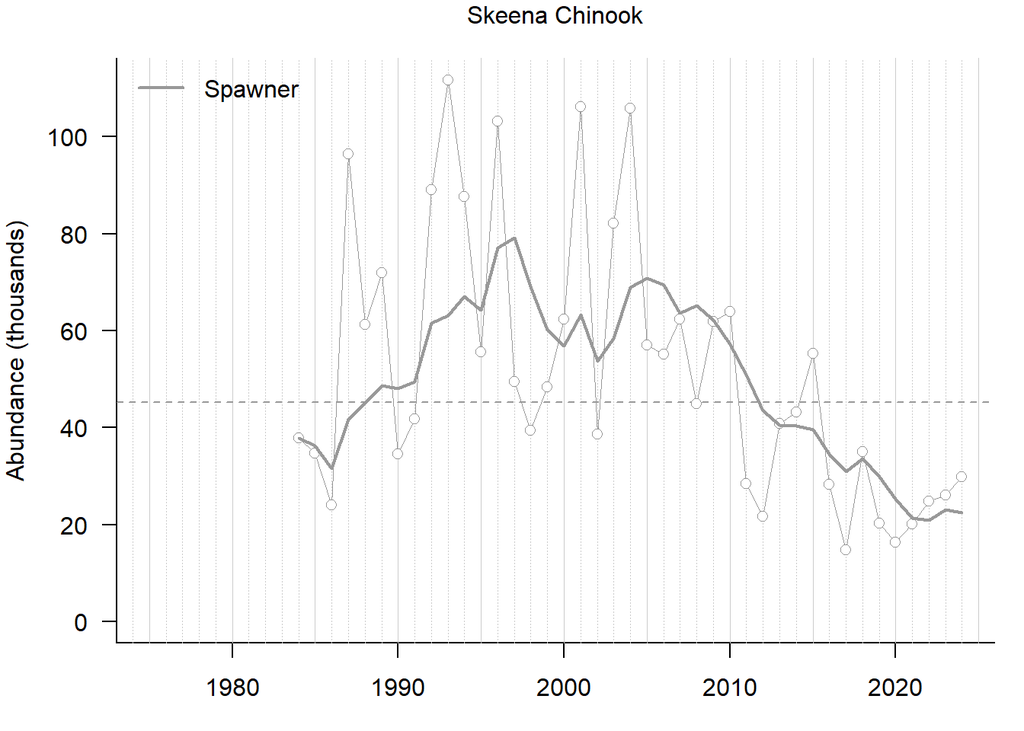

**Above:**Spawner abundance of Skeena chinook salmon. The raw data is shown by points and the smoothed metric by solid lines. Dashed horizonal lines represent the long-term average.

```r
# Load data ---
# TCCHINOOK Table B3
sk_ctc <- readxl::read_xlsx("../data/TCCHINOOK-25-02-Appendix-B-Escapement-Detailed.xlsx", sheet = "B3", range = "A5:G54", col_types = "numeric", col_names = c("Year", "Nass_Above_Gitwinksihlkw2", "Nass_Esc", "Nass_t.run", "Skeena_Total esc.", "Skeena_GSI esc", "Skeena_GSI SD"))

# Reformat data for SPS
skck_sps <- data.frame(
    region = rep("Skeena", length(sk_ctc$Year)),
    species = rep("Chinook", length(sk_ctc$Year)),
    year = sk_ctc$Year,
    spawners = sk_ctc$`Skeena_GSI esc`,
    smoothedSpawners = NA,
    runsize = NA,
    smoothedRunsize = NA,
    source_id = rep(ctc_id, length(sk_ctc$Year))
)

# Smoothing
skck_sps$smoothedSpawners <- genSmooth(
    abund = skck_sps$spawners,
    years = skck_sps$year,
    genLength = genLength$gen_length[genLength$region == "Skeena" & genLength$species == "Chinook"]
)

# Add to master sps dataframe
sps_data <- rbind(sps_data, skck_sps)

#Generate standard figure
plot_abund(skck_sps)
```

#### Sockeye

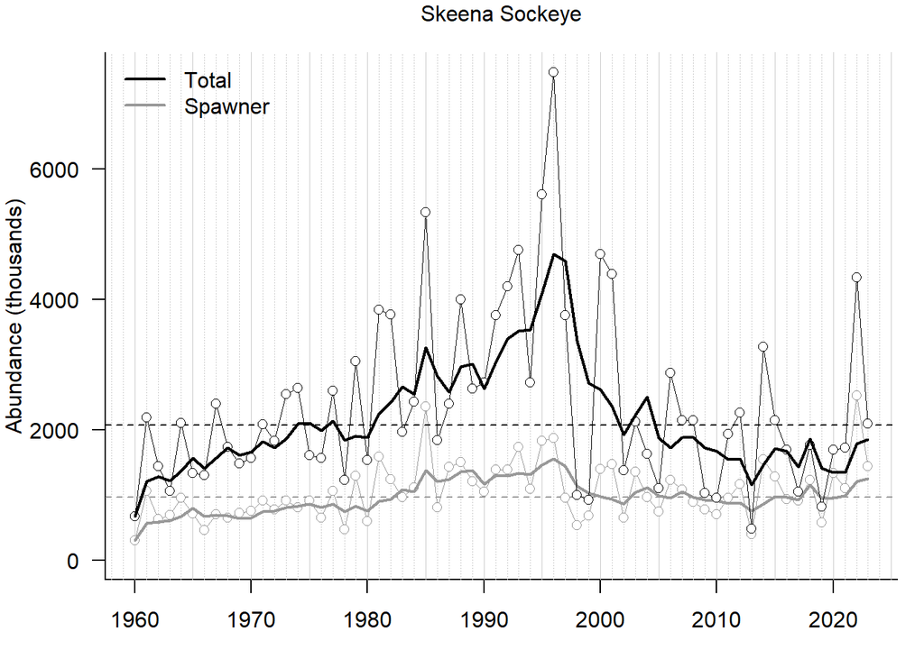

**Above:**Spawner abundance (grey) and total abundance (black) of Skeena sockeye salmon. For both, the raw data is shown by points and the smoothed metric by solid lines. Dashed horizonal lines represent the long-term average for each.

```r
# Compare to NCC run reconstruction: https://github.com/LGLLimited/nccdbv2/tree/master/run/2022-nass-update/data/KarlEnglish-2023-05-29
skse_LGL <- read.csv("../data/nassskeena_sockeye_lgl.csv") %>%
    subset(Region == "Skeena") %>%
    mutate(source_id = "English_20230930")

# From PSC Run Size app:
skse_ch2 <- read.csv("../data/Chapter2_Data_2025_07_22.csv") %>%
    filter(Region == "Skeena River") %>%
    mutate(source_id = "PSC_20250722")

# Add recent year's data from Charmaine (pers. comm. July 24 2025)
skse_2023 <- data.frame(
    Year = 2023,
    TE = 1437788,
    catch = 656984
) %>%
    mutate(Total.Run = TE + catch,
    source_id = "CarrHarris_20250724")

# combine sources
skse <- skse_ch2[ , c("Year", "Spawners", "Returns", "source_id")] %>%
    rename(TE = Spawners,
                 Total.Run  = Returns) %>%
    bind_rows(skse_LGL[which(skse_LGL$Year < 1982), c("Year", "TE", "Total.Run", "source_id")]) %>%
    bind_rows(skse_2023[ c("Year", "TE", "Total.Run", "source_id")]) %>%
    arrange(Year)


#unique(diff(skse$Year)) # Yes, all one year apart

# Reformat data for SPS
skse_sps <- data.frame(
    region = rep("Skeena", dim(skse)[1]),
    species = rep("Sockeye", dim(skse)[1]),
    year = skse$Year,
    spawners = skse$TE,
    smoothedSpawners = NA,
    runsize = skse$Total.Run,
    smoothedRunsize = NA,
    source_id = skse$source_id
)

# Smoothing
skse_sps$smoothedSpawners <- genSmooth(
    abund = skse_sps$spawners,
    years = skse_sps$year,
    genLength = genLength$gen_length[genLength$region == "Skeena" & genLength$species == "Sockeye"]
)

skse_sps$smoothedRunsize <- genSmooth(
    abund = skse_sps$runsize,
    years = skse_sps$year,
    genLength = genLength$gen_length[genLength$region == "Skeena" & genLength$species == "Sockeye"]
)

# Add to master sps dataframe
sps_data <- rbind(sps_data, skse_sps)

# Generate standard figure
plot_abund(skse_sps)
```

#### Steelhead

The index of Skeena steelhead spawner abundance is derived from estimated escapement of Skeena Summer steelhead at the Tyee Test Fishery (1956 - present), provided by the Province via email. As for other regions, these estimates may not capture winter-run steelhead, for which data are not available.

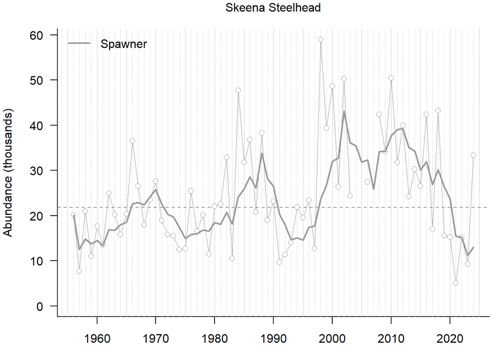

**Above:**Spawner abundance of Skeena steelhead salmon. The raw data is shown by points and the smoothed metric by solid lines. Dashed horizonal lines represent the long-term average.

```r
# Load data ---
# Use Skeena steelhead run size from BC Updates
sksh <- read.csv("../data/SkeenaSteelhead_1956-2024.csv")


# Reformat data for SPS
sksh_sps <- data.frame(
    region = rep("Skeena", dim(sksh)[1]),
    species = rep("Steelhead", dim(sksh)[1]),
    year = sksh$Year,
    spawners = sksh$TyeeEscapement,
    smoothedSpawners = NA,
    runsize = NA,
    smoothedRunsize = NA,
    source_id = "ProvBC_20240929"
)

# Smoothing
sksh_sps$smoothedSpawners <- genSmooth(
    abund = sksh_sps$spawners,
    years = sksh_sps$year,
    genLength = genLength$gen_length[genLength$region == "Skeena" & genLength$species == "Steelhead"]
)

# Add to master sps dataframe
sps_data <- rbind(sps_data, sksh_sps)

# Generate standard figure
plot_abund(sksh_sps)
```

#### Chum

Chum salmon spawner abundances in the Skeena were expanded from available spawner surveys, as described below in Expansion Factors. Note that the designation of indicator streams for the Skeena region was based on English et al. (2018) rather than the indicator designation in NuSEDS.

```r
region_spawners <- sp <- readRDS("../output/expanded-spawners/Skeena-spawners.rds")
yrs <- as.numeric(dimnames(sp)[[3]])
expansion_factors <- readRDS("../output/expanded-spawners/Skeena-expansion-factors.rds")

sk_table32 <- read.csv("../data/TCNB-23-01_Table32_Area4escapement.csv")
names(sk_table32) <- c("year", "Sockeye", "Coho", "Pink", "Chum", "Chinook") # Change names to be consistent with species
```

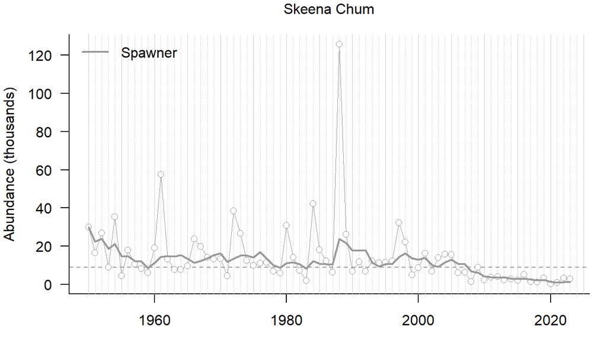

**Above:**Spawner abundance of Skeena chum salmon. The raw data is shown by points and the smoothed metric by solid lines. Dashed horizonal lines represent the long-term average.

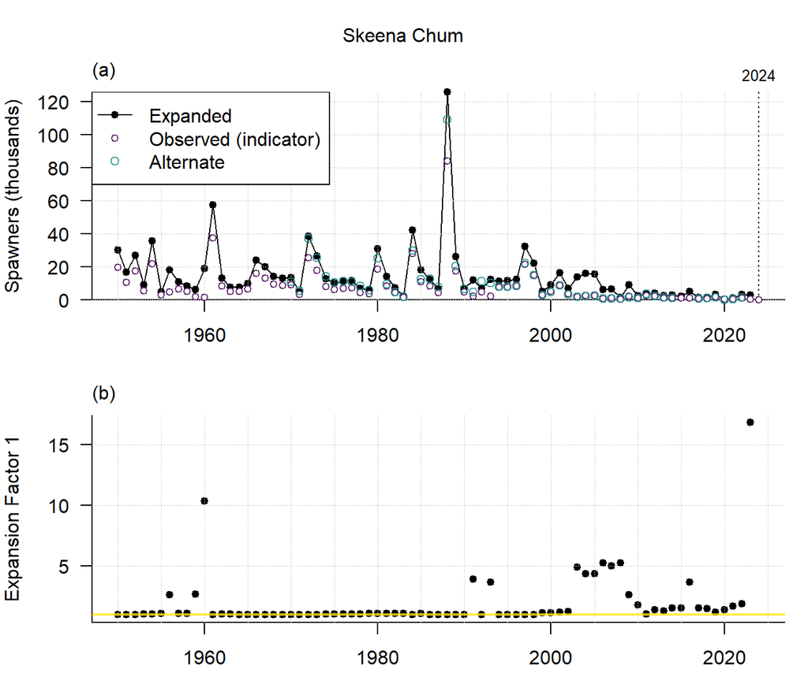

**Above:** (a) Time series of spawner abundances showing raw sum of counts for indicator streams (purple) and expanded estimates of spawner abudnance to indicator and non-indicator streams (black). This expanded time series is what is used to assess the current state and trends in spawner abundance for the region and species. Alternative time series from the PSC’s Northern Boundary Technical Committee Report (Appendix 32) is shown in blue. (b) The values of Expansion Factor 1 that accounts for unmonitored indicator streams in a given year, and is calculated based on the proportional contribution of the unmonitored indicator stream(s) to the sum of all indicator streams in a (reference) decade. See section on Expansion Factors below for further details.

```r
## Process data
skeena.s <- sp[2, "Chum", ]
skeena.s <- skeena.s[!is.na(skeena.s)]

# Reformat data for SPS
skeena.s_sps <- data.frame(
    region = rep("Skeena", length(skeena.s)),
    species = rep("Chum", length(skeena.s)),
    year = as.numeric(names(skeena.s)),
    spawners = as.numeric(skeena.s),
    smoothedSpawners = NA,
    runsize = NA,
    smoothedRunsize = NA,
    source_id = rep(nuseds_id, length(skeena.s))
)

# Smoothing
skeena.s_sps$smoothedSpawners <- genSmooth(
    abund = skeena.s_sps$spawners,
    years = skeena.s_sps$year,
    genLength = genLength$gen_length[genLength$region == "Skeena" & genLength$species == "Chum"]
)

# Add to master sps dataframe
sps_data <- rbind(sps_data, skeena.s_sps)

# Generate standard figure
plot_abund(skeena.s_sps)
```

#### Coho

Coho salmon spawner abundances in the Skeena were expanded from available spawner surveys, as described below in Expansion Factors. Note that the designation of indicator streams for the Skeena region was based on English et al. (2018) rather than the indicator designation in NuSEDS.

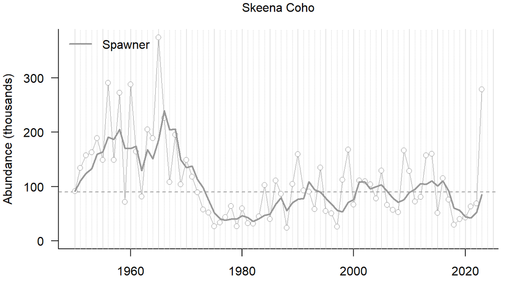

**Above:**Spawner abundance of Skeena coho salmon. The raw data is shown by points and the smoothed metric by solid lines. Dashed horizonal lines represent the long-term average.

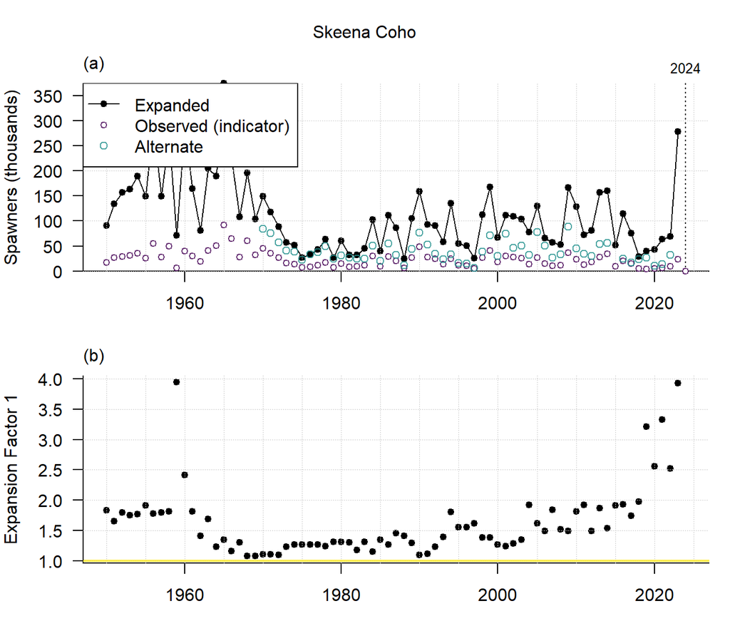

**Above:** (a) Time series of spawner abundances showing raw sum of counts for indicator streams (purple) and expanded estimates of spawner abudnance to indicator and non-indicator streams (black). This expanded time series is what is used to assess the current state and trends in spawner abundance for the region and species. Alternative time series from the PSC’s Northern Boundary Technical Committee Report (Appendix 32) is shown in blue. (b) The values of Expansion Factor 1 that accounts for unmonitored indicator streams in a given year, and is calculated based on the proportional contribution of the unmonitored indicator stream(s) to the sum of all indicator streams in a (reference) decade. See section on Expansion Factors below for further details.

```r
## Process data
skeena.s <- sp[2, "Coho", ]
skeena.s <- skeena.s[!is.na(skeena.s)]

# Reformat data for SPS
skeena.s_sps <- data.frame(
    region = rep("Skeena", length(skeena.s)),
    species = rep("Coho", length(skeena.s)),
    year = as.numeric(names(skeena.s)),
    spawners = as.numeric(skeena.s),
    smoothedSpawners = NA,
    runsize = NA,
    smoothedRunsize = NA,
    source_id = rep(nuseds_id, length(skeena.s))
)

# Smoothing
skeena.s_sps$smoothedSpawners <- genSmooth(
    abund = skeena.s_sps$spawners,
    years = skeena.s_sps$year,
    genLength = genLength$gen_length[genLength$region == "Skeena" & genLength$species == "Coho"]
)

# Add to master sps dataframe
sps_data <- rbind(sps_data, skeena.s_sps)

# Generate standard figure
plot_abund(skeena.s_sps)
```